# Exploration

Sophia Drewry

10/13/2021

This script loads the processed data does some exploration to prepare for the formal statistical fitting

### Load needed packages

```r
library(dplyr) #for data processing
library(here) #to set paths
library(gtsummary)
library(table1)
```

```r
library(ggplot2)
library(tidyr)
library(survey)
library(ggthemes)
library(RColorBrewer)
library(reshape2)
# path to data
# note the use of the here() package and not absolute paths
dataSPOT <- here::here("data","processed_data","processeddta.rds")

# load data.
processeddta <-readRDS(dataSPOT)

# take a look at the data
dplyr::glimpse(processeddta)
```

```
## Rows: 730
## Columns: 32
## $ SwollenLymphNodes <fct> Yes, Yes, Yes, Yes, Yes, No, No, No, Yes, No, Yes, Y…
## $ ChestCongestion   <fct> No, Yes, Yes, Yes, No, No, No, Yes, Yes, Yes, Yes, Y…
## $ ChillsSweats      <fct> No, No, Yes, Yes, Yes, Yes, Yes, Yes, Yes, No, Yes, …
## $ NasalCongestion   <fct> No, Yes, Yes, Yes, No, No, No, Yes, Yes, Yes, Yes, Y…
## $ CoughYN           <fct> Yes, Yes, No, Yes, No, Yes, Yes, Yes, Yes, Yes, No, …
## $ Sneeze            <fct> No, No, Yes, Yes, No, Yes, No, Yes, No, No, No, No, …
## $ Fatigue           <fct> Yes, Yes, Yes, Yes, Yes, Yes, Yes, Yes, Yes, Yes, Ye…
## $ SubjectiveFever   <fct> Yes, Yes, Yes, Yes, Yes, Yes, Yes, Yes, Yes, No, Yes…
## $ Headache          <fct> Yes, Yes, Yes, Yes, Yes, Yes, No, Yes, Yes, Yes, Yes…
## $ Weakness          <fct> Mild, Severe, Severe, Severe, Moderate, Moderate, Mi…
## $ WeaknessYN        <fct> Yes, Yes, Yes, Yes, Yes, Yes, Yes, Yes, Yes, Yes, Ye…
## $ CoughIntensity    <fct> Severe, Severe, Mild, Moderate, None, Moderate, Seve…
## $ CoughYN2          <fct> Yes, Yes, Yes, Yes, No, Yes, Yes, Yes, Yes, Yes, Yes…
```

[output cut: 19 more lines]

### End goal:

- Main continuous outcome of interest = Body temperature
- Main categorical outcome = Nausea
- We want to see if the other symptoms are correlated with (predict) those outcomes
- Not as important now since this script is just EDA, but its important to keep in mind

```r
## Table one
# Lets get a good understanding of our variables in table form

# I want to produce a quick table to see the most common symptoms
processeddta %>% tbl_summary() %>%
  modify_caption("**Table 1. Patient Characteristics**")
```

**Table 1. Patient Characteristics**

| **Characteristic** | **N = 730**<sup>1</sup> |
| --- | --- |
| SwollenLymphNodes | 312 (43%) |
| ChestCongestion | 407 (56%) |
| ChillsSweats | 600 (82%) |
| NasalCongestion | 563 (77%) |
| CoughYN | 655 (90%) |
| Sneeze | 391 (54%) |
| Fatigue | 666 (91%) |
| SubjectiveFever | 500 (68%) |
| Headache | 615 (84%) |
| Weakness |  |
| None | 49 (6.7%) |
| Mild | 223 (31%) |
| Moderate | 338 (46%) |
| Severe | 120 (16%) |
| WeaknessYN | 681 (93%) |
| CoughIntensity |  |
| None | 47 (6.4%) |
| Mild | 154 (21%) |
| Moderate | 357 (49%) |
| Severe | 172 (24%) |
| CoughYN2 | 683 (94%) |
| Myalgia |  |
| None | 79 (11%) |
| Mild | 213 (29%) |
| Moderate | 325 (45%) |
| Severe | 113 (15%) |
| MyalgiaYN | 651 (89%) |
| RunnyNose | 519 (71%) |
| AbPain | 91 (12%) |
| ChestPain | 233 (32%) |
| Diarrhea | 99 (14%) |
| EyePn | 113 (15%) |
| Insomnia | 415 (57%) |
| ItchyEye | 179 (25%) |
| Nausea | 255 (35%) |
| EarPn | 162 (22%) |
| Hearing | 30 (4.1%) |
| Pharyngitis | 611 (84%) |
| Breathless | 294 (40%) |
| ToothPn | 165 (23%) |
| Vision | 19 (2.6%) |
| Vomit | 78 (11%) |
| Wheeze | 220 (30%) |
| BodyTemp | 98.50 (98.20, 99.30) |

<sup>*1*</sup> n (%); Median (IQR)

## Ok the ones that look interesting to me are…

- Fatigue (y/n)
- CoughIntensity (none/mild/moderate/severe)
- ChillsSweats (y/n)
- SwollenLymphNodes (y/n)
- Pharyngitis (y/n)
- Insomnia (y/n)
- Headache (y/n)
- SubjectiveFever (y/n)

# Exploring Nausea Variable

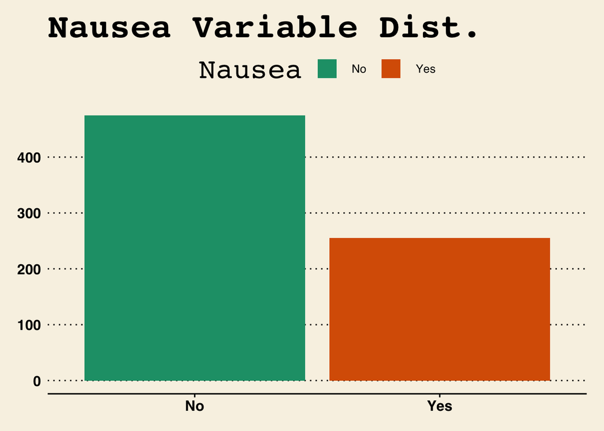

```r
# Plotting Nausea Variable
processeddta %>% ggplot(aes(x=Nausea, fill=Nausea)) +
  geom_bar() +
  labs(title= "Nausea Variable Dist.") +
  theme_wsj() +
  scale_fill_brewer(palette = "Dark2")
```

```r
# Lets look at the variable distributions compared to Nausea
processeddta %>%
  select("Nausea", "Fatigue", "CoughIntensity", "ChillsSweats", "SwollenLymphNodes","Pharyngitis", "Insomnia", "Headache", "SubjectiveFever") %>%
  tbl_summary(by = Nausea) %>%
  modify_caption("**Table 2. Patient Characteristics vs. Nausea**")
```

**Table 2. Patient Characteristics vs. Nausea**

| **Characteristic** | **No**, N = 475<sup>1</sup> | **Yes**, N = 255<sup>1</sup> |
| --- | --- | --- |
| Fatigue | 424 (89%) | 242 (95%) |
| CoughIntensity |  |  |
| None | 30 (6.3%) | 17 (6.7%) |
| Mild | 99 (21%) | 55 (22%) |
| Moderate | 232 (49%) | 125 (49%) |
| Severe | 114 (24%) | 58 (23%) |
| ChillsSweats | 372 (78%) | 228 (89%) |
| SwollenLymphNodes | 200 (42%) | 112 (44%) |
| Pharyngitis | 395 (83%) | 216 (85%) |
| Insomnia | 260 (55%) | 155 (61%) |
| Headache | 387 (81%) | 228 (89%) |
| SubjectiveFever | 309 (65%) | 191 (75%) |

<sup>*1*</sup> n (%)

Nausea, Fatigue, Chills Sweats, Pharyngitis, and Headache seem to be the most common among those with Nausea. For no we will keep all the variables, lets look at them in bar plots

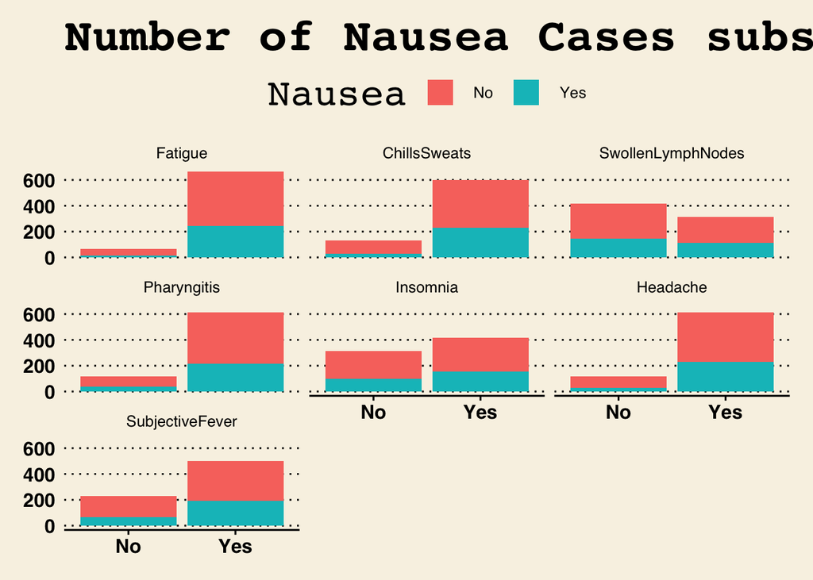

```r
# Now lets separate them
nauseads <- processeddta[, c("Nausea", "Fatigue", "ChillsSweats", "SwollenLymphNodes","Pharyngitis", "Insomnia", "Headache", "SubjectiveFever")]

# Changing the data format so we can graph together
uglytry<-melt(nauseads, id.vars = c("Nausea"))
# Not including "CoughIntensity" because it makes graphing complicated
# Note, the new names are Nausea, variable, value

# Now to graph the frequency of Nausea Cases subset by Symptoms
uglytry %>% ggplot(aes(x=value, fill=Nausea)) +
  geom_bar() +
  labs(title= "Number of Nausea Cases subset by Symptoms") +
  facet_wrap(~variable) +
  theme_wsj()
```

This looks interesting, lets see if we can see it as a proportion

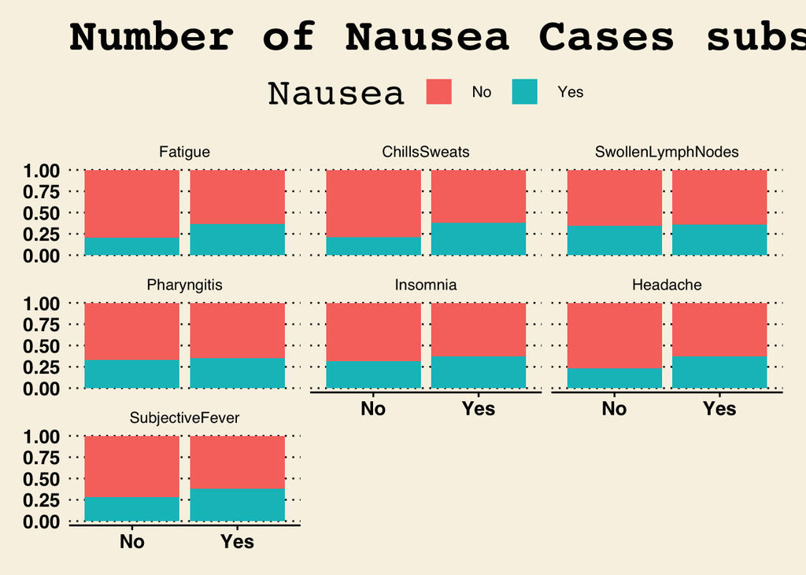

```r
uglytry %>% ggplot(aes(x=value, fill=Nausea)) +
  geom_bar(position="fill") +
  labs(title= "Number of Nausea Cases subset by Symptoms") +
  facet_wrap(~variable) +
  theme_wsj()
```

Not as exciting. Nausea distribution seems to differ slightly in fatigue, chill sweats and headache Now lets move on to body temperature